# Project Python Foundations: FoodHub Data Analysis

### **Question 7**: Which are the top 5 restaurants in terms of the number of orders received? [1 mark]

```python
# Top 5 restaurants with highest number of orders
df.restaurant_name.value_counts().head()
```

```
Shake Shack                  219
The Meatball Shop            132
Blue Ribbon Sushi            119
Blue Ribbon Fried Chicken     96
Parm                          68
Name: restaurant_name, dtype: int64
```

Observations: "Shake Shack" restaurant received highest orders of 219 and at the bottom in top 5 is "Parm" restaurant.

### **Question 8**: Which is the most popular cuisine on weekends? [1 mark]

```python
# The most popular cuisine on weekends
df_weekend = df.cuisine_type[df.day_of_the_week == 'Weekend']
df_weekend.value_counts(sort =True) ## Complete the code to check unique values for the cuisine type on weekend
```

```
American          415
Japanese          335
Italian           207
Chinese           163
Mexican            53
Indian             49
Mediterranean      32
Middle Eastern     32
Thai               15
French             13
Korean             11
Southern           11
Spanish            11
Vietnamese          4
Name: cuisine_type, dtype: int64
```

#### Observations: American, Japanese, Italian, Chinese and Mexican are the top 5 cuisine types most ordered by customers on the weekends.

### **Question 9**: What percentage of the orders cost more than 20 dollars? [2 marks]

```python
# Get orders that cost above 20 dollars
df_greater_than_20 = df[df["cost_of_the_order"]>20] ## Write the appropriate column name to get the orders having cost above $20

# Calculate the number of total orders where the cost is above 20 dollars
print('The number of total orders that cost above 20 dollars is:', df_greater_than_20.shape[0])

# Calculate percentage of such orders in the dataset
percentage = (df_greater_than_20.shape[0] / df.shape[0]) * 100

print("Percentage of orders above 20 dollars:", round(percentage, 2), '%')
```

```
The number of total orders that cost above 20 dollars is: 555
Percentage of orders above 20 dollars: 29.24 %
```

#### Observations: Approximately, 30 % of orders placed are above 20 dollars.

### **Question 10**: What is the mean order delivery time? [1 mark]

```python
# Get the mean delivery time
mean_del_time = df['delivery_time'].mean()  ## Write the appropriate function to obtain the mean delivery time

print('The mean delivery time for this dataset is', round(mean_del_time, 2), 'minutes')
```

```
The mean delivery time for this dataset is 24.16 minutes
```

#### Observations: The mean delivery time for this dataset is 24.16 minutes

### **Question 11:** The company has decided to give 20% discount vouchers to the top 3 most frequent customers. Find the IDs of these customers and the number of orders they placed. [1 mark]

```python
# Get the counts of  each customer_id
df["customer_id"].value_counts(sort=True)[0:5]  ## Write the appropriate column name to get the top 5 cmost frequent customers
```

```
52832     13
47440     10
83287      9
250494     8
259341     7
Name: customer_id, dtype: int64
```

#### Observations: Top 3 ustomers are (52832,47440 & 83287) placed orders 13, 10 & 9 respectively and they are eligible for 20% discount.

### **Question 12**: Perform a multivariate analysis to explore relationships between the important variables in the dataset. (It is a good idea to explore relations between numerical variables as well as relations between numerical and categorical variables) [10 marks]

**Cuisine vs Cost of the order**

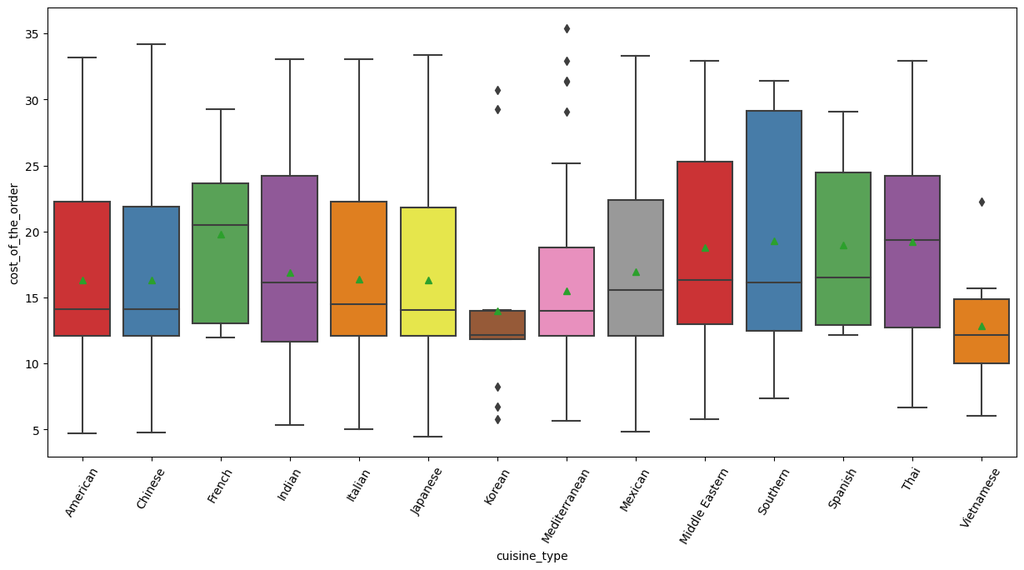

```python
# Relationship between cost of the order and cuisine type
plt.figure(figsize=(15,7))
sns.boxplot(x = "cuisine_type", y = "cost_of_the_order", data = df, showmeans = True, palette = 'Set1')
plt.xticks(rotation = 60)
plt.show()
plt.savefig("output.jpg", bbox_inches='tight')
```

**Cuisine vs Food Preparation time**

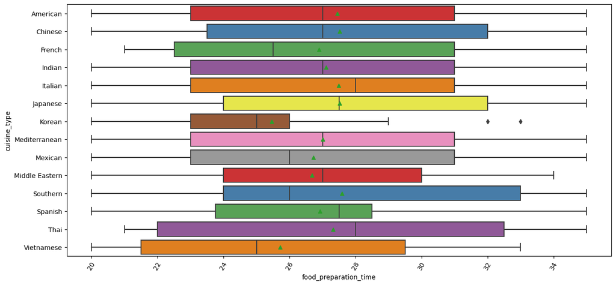

```python
# Relationship between food preparation time and cuisine type
plt.figure(figsize=(15,7))
sns.boxplot(x='food_preparation_time',y='cuisine_type', data = df, showmeans = True, palette = 'Set1')  ## Complete the code to visualize the relationship between food preparation time and cuisine type using boxplot
plt.xticks(rotation = 60)
plt.show()
plt.savefig("output.jpg", bbox_inches='tight')
```

**Day of the Week vs Delivery time**

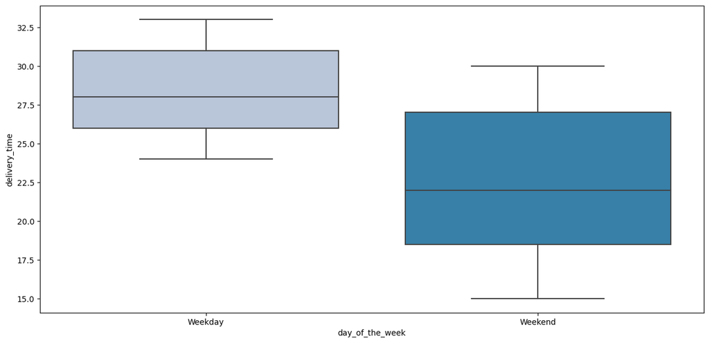

```python
# Relationship between day of the week and delivery time
plt.figure(figsize=(15,7))
sns.boxplot(x='day_of_the_week',y='delivery_time', data = df, palette='PuBu')  ## Complete the code to visualize the relationship between day of the week and delivery time using boxplot
plt.show()
plt.savefig("output.jpg", bbox_inches='tight')
```

* Observations on the revenue generated by the restaurants.

```python
df.groupby(['restaurant_name'])['cost_of_the_order'].sum().sort_values(ascending = False).head(14)
```

```
restaurant_name
Shake Shack                     3579.53
The Meatball Shop               2145.21
Blue Ribbon Sushi               1903.95
Blue Ribbon Fried Chicken       1662.29
Parm                            1112.76
RedFarm Broadway                 965.13
RedFarm Hudson                   921.21
TAO                              834.50
Han Dynasty                      755.29
Blue Ribbon Sushi Bar & Grill    666.62
Rubirosa                         660.45
Sushi of Gari 46                 640.87
Nobu Next Door                   623.67
Five Guys Burgers and Fries      506.47
Name: cost_of_the_order, dtype: float64
```

**Rating vs Delivery time**

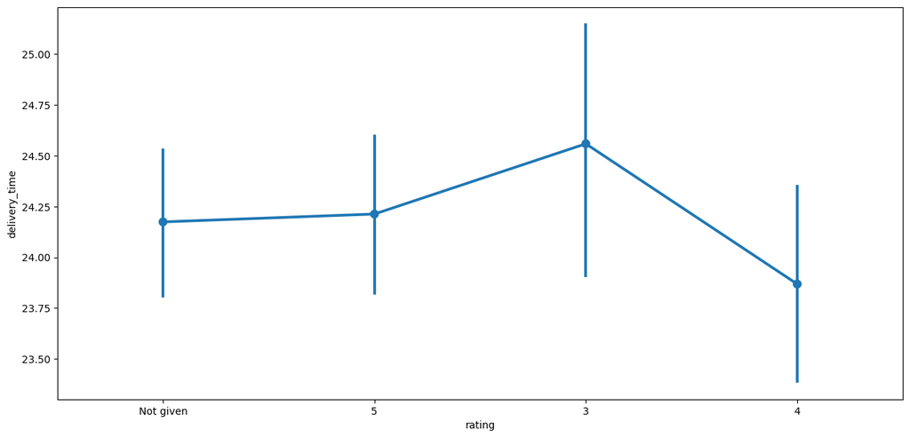

```python
# Relationship between rating and delivery time
plt.figure(figsize=(15, 7))
sns.pointplot(x = 'rating', y = 'delivery_time', data = df)
plt.show()
plt.savefig("output.jpg", bbox_inches='tight')
```

**Rating vs Food preparation time**

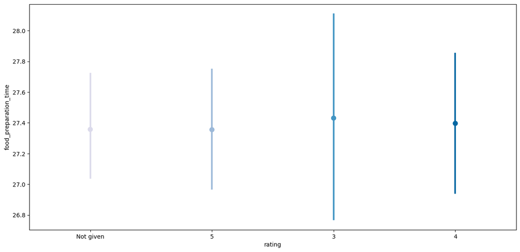

```python
# Relationship between rating and food preparation time
plt.figure(figsize=(15, 7))
sns.pointplot(x='rating',y='food_preparation_time', data = df, palette='PuBu')  ## Complete the code to visualize the relationship between rating and food preparation time using pointplot
plt.show()
plt.savefig("output.jpg", bbox_inches='tight')
```

**Rating vs Cost of the order**

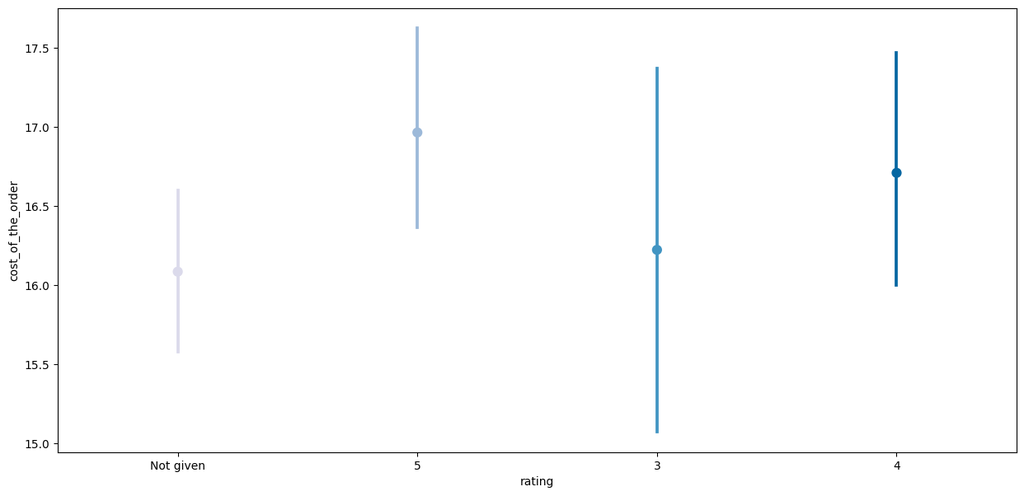

```python
# Relationship between rating and cost of the order
plt.figure(figsize=(15, 7))
sns.pointplot(x='rating',y='cost_of_the_order', data = df, palette='PuBu')   ## Code to visualize the relationship between rating and cost of the order using pointplot
plt.show()
plt.savefig("output.jpg", bbox_inches='tight')
```

**Correlation among variables**

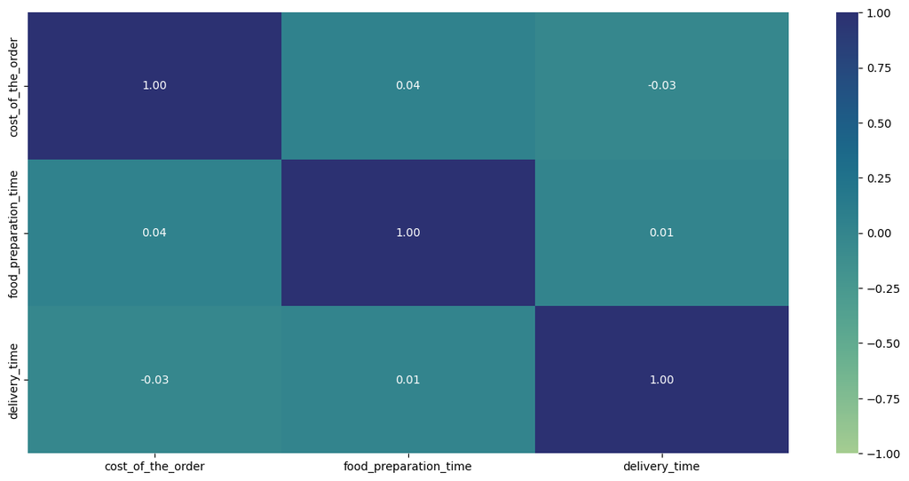

```python
# Plot the heatmap
col_list = ['cost_of_the_order', 'food_preparation_time', 'delivery_time']
plt.figure(figsize=(15, 7))
sns.heatmap(df[col_list].corr(), annot=True, vmin=-1, vmax=1, fmt=".2f", cmap="crest")
plt.show()
plt.savefig("output.jpg", bbox_inches='tight')
```

Observations:

### **Question 13:** The company wants to provide a promotional offer in the advertisement of the restaurants. The condition to get the offer is that the restaurants must have a rating count of more than 50 and the average rating should be greater than 4. Find the restaurants fulfilling the criteria to get the promotional offer. [3 marks]

```python
# Filter the rated restaurants
df_rated = df[df['rating'] != 'Not given'].copy()

# Convert rating column from object to integer
df_rated['rating'] = df_rated['rating'].astype('int')

# Create a dataframe that contains the restaurant names with their rating counts
df_rating_count = df_rated.groupby(['restaurant_name'])['rating'].count().sort_values(ascending = False).reset_index()
df_rating_count.head()
```

|  | restaurant_name | rating |
| --- | --- | --- |
| 0 | Shake Shack | 133 |
| 1 | The Meatball Shop | 84 |
| 2 | Blue Ribbon Sushi | 73 |
| 3 | Blue Ribbon Fried Chicken | 64 |
| 4 | RedFarm Broadway | 41 |

```python
df_rating_count['restaurant_name'][df_rating_count['rating'] >50]
```

```
0                  Shake Shack
1            The Meatball Shop
2            Blue Ribbon Sushi
3    Blue Ribbon Fried Chicken
Name: restaurant_name, dtype: category
Categories (178, object): [''wichcraft', '12 Chairs', '5 Napkin Burger', '67 Burger', ..., 'brgr',
                           'da Umberto', 'ilili Restaurant', 'indikitch']
```

```python
# Get the restaurant names that have rating count more than 50
rest_names = df_rating_count['restaurant_name'][df_rating_count['rating'] >50] ## Complete the code to get the restaurant names having rating count more than 50

# Filter to get the data of restaurants that have rating count more than 50
df_mean_4 = df_rated[df_rated['restaurant_name'].isin(rest_names)].copy()

# Group the restaurant names with their ratings and find the mean rating of each restaurant
df_mean_4.groupby(["restaurant_name"])['rating'].mean().sort_values(ascending = False).reset_index().dropna() ## Complete the code to find the mean rating
```

|  | restaurant_name | rating |
| --- | --- | --- |
| 0 | The Meatball Shop | 4.51 |
| 1 | Blue Ribbon Fried Chicken | 4.33 |
| 2 | Shake Shack | 4.28 |
| 3 | Blue Ribbon Sushi | 4.22 |

#### Observations: Top 4 restaurants with thier mean rating.

### **Question 14:** The company charges the restaurant 25% on the orders having cost greater than 20 dollars and 15% on the orders having cost greater than 5 dollars. Find the net revenue generated by the company across all orders. [3 marks]

```python
#function to determine the revenue
def compute_rev(x):
    if x > 20:
        return x*0.25
    elif x > 5:
        return x*0.15
    else:
        return x*0

df['Revenue'] = df['cost_of_the_order'].apply(compute_rev) ## Write the apprpriate column name to compute the revenue
df.head()
```

|  | order_id | customer_id | restaurant_name | cuisine_type | cost_of_the_order | day_of_the_week | rating | food_preparation_time | delivery_time | Revenue |
| --- | --- | --- | --- | --- | --- | --- | --- | --- | --- | --- |
| 0 | 1477147 | 337525 | Hangawi | Korean | 30.75 | Weekend | Not given | 25 | 20 | 7.69 |
| 1 | 1477685 | 358141 | Blue Ribbon Sushi Izakaya | Japanese | 12.08 | Weekend | Not given | 25 | 23 | 1.81 |
| 2 | 1477070 | 66393 | Cafe Habana | Mexican | 12.23 | Weekday | 5 | 23 | 28 | 1.83 |
| 3 | 1477334 | 106968 | Blue Ribbon Fried Chicken | American | 29.20 | Weekend | 3 | 25 | 15 | 7.30 |
| 4 | 1478249 | 76942 | Dirty Bird to Go | American | 11.59 | Weekday | 4 | 25 | 24 | 1.74 |

```python
# get the total revenue and print it
total_rev = df['Revenue'].sum() ## Write the appropriate function to get the total revenue
print('The net revenue is around', round(total_rev, 2), 'dollars')
```

```
The net revenue is around 6166.3 dollars
```

### **Question 15:** The company wants to analyze the total time required to deliver the food. What percentage of orders take more than 60 minutes to get delivered from the time the order is placed? (The food has to be prepared and then delivered.) [2 marks]

```python
# Calculate total delivery time and add a new column to the dataframe df to store the total delivery time
df['total_time'] = df['food_preparation_time'] + df['delivery_time']


## Write the code below to find the percentage of orders that have more than 60 minutes of total delivery time (see Question 9 for reference)

# Get orders that have total delivery time more than 60 mins
df_greater_than_60 = df[df["total_time"]>60] ## Write the appropriate column name to get the orders having total time above 60 mins

# Calculate the number of total orders where the total delivery time is above 60 mins
print('The total delivery time above 60 mins is:', df_greater_than_60.shape[0])

percentage = (df_greater_than_60.shape[0] / df.shape[0]) * 100

print("Percentage of total delivery time:", round(percentage, 2), '%')
```

```
The total delivery time above 60 mins is: 200
Percentage of total delivery time: 10.54 %
```

#### Observations: The total delivery time above 60 mins is: 200 orders.

Percentage of total delivery time: 10.54 %

### **Question 16:** The company wants to analyze the delivery time of the orders on weekdays and weekends. How does the mean delivery time vary during weekdays and weekends? [2 marks]

```python
# Get the mean delivery time on weekdays and print it
print('The mean delivery time on weekdays is around',
      round(df[df['day_of_the_week'] == 'Weekday']['delivery_time'].mean()),
     'minutes')


## Write the code below to get the mean delivery time on weekends and print it


print('The mean delivery time on weekends is around',
      round(df[df['day_of_the_week'] == 'Weekend']['delivery_time'].mean()),
     'minutes')
```

```
The mean delivery time on weekdays is around 28 minutes
The mean delivery time on weekends is around 22 minutes
```

### Conclusion and Recommendations

### **Question 17:** What are your conclusions from the analysis? What recommendations would you like to share to help improve the business? (You can use cuisine type and feedback ratings to drive your business recommendations.) [6 marks]

### Conclusions:

- The number of orders that have not been rated is large (38.78 %) compared to the total number of orders
- The Coefficient of variation CV for the 'cost of the order' (0.45) is higher compared to 'Food Preparation time' (0.17) and 'Delivery time' (0.21)
- There is no correlation between the numerical variables as well as 'Total time' and 'Cost of the order'
- American, Japanese, Italian & Chinese are the top 4 cuisine types  
  most ordered by customers
- Top 3 customers are (52832, 47440 & 83287) placed orders 13, 10 & 9 respectively and they are eligible for 20% discount as company mentioned above.